# Linear Regression

Problem Statement: A real estate agent wants to help predict housing prices for regions in the USA. Let us create a model that allows to put in a few features of a house and returns back an estimate of what the house would sell for.

Linear Regression might be a good path to solve this problem!

The data contains the following columns:

'Avg. Area Income': Avg. Income of residents of the city where the house is located in.

'Avg. Area House Age': Avg Age of Houses in same city

'Avg. Area Number of Rooms': Avg Number of Rooms for Houses in same city

'Avg. Area Number of Bedrooms': Avg Number of Bedrooms for Houses in same city

'Area Population': Population of city where the house is located in

'Price': Price that the house sold at

'Address': Address of the house

# Import Libraries

```python
import pandas as pd
import numpy as np
import seaborn as sns
import matplotlib.pyplot as plt
%matplotlib inline
```

# Check out the Data

```python
df=pd.read_csv('C:\\Users\\Windows\\Desktop\\data sci\\Linear Regression\\Linear Regression\\Python\\USA_Housing.csv')
```

```python
df.head()
```

|  | Avg. Area Income | Avg. Area House Age | Avg. Area Number of Rooms | Avg. Area Number of Bedrooms | Area Population | Price | Address |
| --- | --- | --- | --- | --- | --- | --- | --- |
| 0 | 79545.458574 | 5.682861 | 7.009188 | 4.09 | 23086.800503 | 1.059034e+06 | 208 Michael Ferry Apt. 674\nLaurabury, NE 3701... |
| 1 | 79248.642455 | 6.002900 | 6.730821 | 3.09 | 40173.072174 | 1.505891e+06 | 188 Johnson Views Suite 079\nLake Kathleen, CA... |
| 2 | 61287.067179 | 5.865890 | 8.512727 | 5.13 | 36882.159400 | 1.058988e+06 | 9127 Elizabeth Stravenue\nDanieltown, WI 06482... |
| 3 | 63345.240046 | 7.188236 | 5.586729 | 3.26 | 34310.242831 | 1.260617e+06 | USS Barnett\nFPO AP 44820 |
| 4 | 59982.197226 | 5.040555 | 7.839388 | 4.23 | 26354.109472 | 6.309435e+05 | USNS Raymond\nFPO AE 09386 |

```python
df.shape
```

```
(5000, 7)
```

```python
df.head(5000)
```

|  | Avg. Area Income | Avg. Area House Age | Avg. Area Number of Rooms | Avg. Area Number of Bedrooms | Area Population | Price | Address |
| --- | --- | --- | --- | --- | --- | --- | --- |
| 0 | 79545.458574 | 5.682861 | 7.009188 | 4.09 | 23086.800503 | 1.059034e+06 | 208 Michael Ferry Apt. 674\nLaurabury, NE 3701... |
| 1 | 79248.642455 | 6.002900 | 6.730821 | 3.09 | 40173.072174 | 1.505891e+06 | 188 Johnson Views Suite 079\nLake Kathleen, CA... |
| 2 | 61287.067179 | 5.865890 | 8.512727 | 5.13 | 36882.159400 | 1.058988e+06 | 9127 Elizabeth Stravenue\nDanieltown, WI 06482... |
| 3 | 63345.240046 | 7.188236 | 5.586729 | 3.26 | 34310.242831 | 1.260617e+06 | USS Barnett\nFPO AP 44820 |
| 4 | 59982.197226 | 5.040555 | 7.839388 | 4.23 | 26354.109472 | 6.309435e+05 | USNS Raymond\nFPO AE 09386 |
| 5 | 80175.754159 | 4.988408 | 6.104512 | 4.04 | 26748.428425 | 1.068138e+06 | 06039 Jennifer Islands Apt. 443\nTracyport, KS... |
| 6 | 64698.463428 | 6.025336 | 8.147760 | 3.41 | 60828.249085 | 1.502056e+06 | 4759 Daniel Shoals Suite 442\nNguyenburgh, CO ... |
| 7 | 78394.339278 | 6.989780 | 6.620478 | 2.42 | 36516.358972 | 1.573937e+06 | 972 Joyce Viaduct\nLake William, TN 17778-6483 |
| 8 | 59927.660813 | 5.362126 | 6.393121 | 2.30 | 29387.396003 | 7.988695e+05 | USS Gilbert\nFPO AA 20957 |
| 9 | 81885.927184 | 4.423672 | 8.167688 | 6.10 | 40149.965749 | 1.545155e+06 | Unit 9446 Box 0958\nDPO AE 97025 |
| 10 | 80527.472083 | 8.093513 | 5.042747 | 4.10 | 47224.359840 | 1.707046e+06 | 6368 John Motorway Suite 700\nJanetbury, NM 26854 |
| 11 | 50593.695497 | 4.496513 | 7.467627 | 4.49 | 34343.991886 | 6.637324e+05 | 911 Castillo Park Apt. 717\nDavisborough, PW 7... |
| 12 | 39033.809237 | 7.671755 | 7.250029 | 3.10 | 39220.361467 | 1.042814e+06 | 209 Natasha Stream Suite 961\nHuffmanland, NE ... |
| 13 | 73163.663441 | 6.919535 | 5.993188 | 2.27 | 32326.123139 | 1.291332e+06 | 829 Welch Track Apt. 992\nNorth John, AR 26532... |
| 14 | 69391.380184 | 5.344776 | 8.406418 | 4.37 | 35521.294033 | 1.402818e+06 | PSC 5330, Box 4420\nAPO AP 08302 |
| 15 | 73091.866746 | 5.443156 | 8.517513 | 4.01 | 23929.524053 | 1.306675e+06 | 2278 Shannon View\nNorth Carriemouth, NM 84617 |
| 16 | 79706.963058 | 5.067890 | 8.219771 | 3.12 | 39717.813576 | 1.556787e+06 | 064 Hayley Unions\nNicholsborough, HI 44161-1887 |
| 17 | 61929.077018 | 4.788550 | 5.097010 | 4.30 | 24595.901498 | 5.284852e+05 | 5498 Rachel Locks\nNew Gregoryshire, PW 54755 |
| 18 | 63508.194299 | 5.947165 | 7.187774 | 5.12 | 35719.653052 | 1.019426e+06 | Unit 7424 Box 2786\nDPO AE 71255 |
| 19 | 62085.276403 | 5.739411 | 7.091808 | 5.49 | 44922.106702 | 1.030591e+06 | 19696 Benjamin Cape\nStephentown, ME 36952-4733 |
| 20 | 86294.999089 | 6.627457 | 8.011898 | 4.07 | 47560.775336 | 2.146925e+06 | 030 Larry Park Suite 665\nThomashaven, HI 8794... |
| 21 | 60835.089979 | 5.551222 | 6.517175 | 2.10 | 45574.741662 | 9.292476e+05 | USNS Brown\nFPO AP 85833 |
| 22 | 64490.650267 | 4.210323 | 5.478088 | 4.31 | 40358.960106 | 7.188872e+05 | 95198 Ortiz Key\nPort Sara, TN 24541-2855 |
| 23 | 60697.351539 | 6.170484 | 7.150537 | 6.34 | 28140.967088 | 7.439998e+05 | 9003 Jay Plains Suite 838\nLake Elizabeth, IN ... |
| 24 | 59748.855487 | 5.339340 | 7.748682 | 4.23 | 27809.986544 | 8.957371e+05 | 24282 Paul Valley\nWest Perry, MI 03169-5806 |
| 25 | 56974.476539 | 8.287562 | 7.312880 | 4.33 | 40694.869513 | 1.453975e+06 | 61938 Brady Falls\nLewisfort, DE 61227 |
| 26 | 82173.626076 | 4.018525 | 6.992699 | 2.03 | 38853.918066 | 1.125693e+06 | 3599 Ramirez Springs\nJacksonhaven, AZ 72798 |
| 27 | 64626.880978 | 5.443360 | 6.988754 | 4.00 | 27784.742280 | 9.754295e+05 | 073 Christopher Falls Suite 882\nWest Cynthia,... |
| 28 | 90499.057451 | 6.384359 | 4.242191 | 3.04 | 33970.164990 | 1.240764e+06 | 6531 Chase Prairie Apt. 245\nSusanshire, MN 22365 |
| 29 | 59323.792100 | 6.977828 | 8.273697 | 4.07 | 37520.657732 | 1.577018e+06 | 17124 Johnson Squares\nLake Robertfurt, AL 618... |
| ... | ... | ... | ... | ... | ... | ... | ... |
| 4970 | 55980.204807 | 7.014510 | 5.458789 | 2.11 | 43968.687046 | 1.120943e+06 | 2558 King Trail\nEast Catherinebury, MP 23625-... |
| 4971 | 73491.134427 | 5.784430 | 4.425959 | 3.37 | 30800.541060 | 1.111307e+06 | 6043 Stevens Stream\nWest Kimberlymouth, ME 49723 |
| 4972 | 83695.272383 | 7.643507 | 7.127219 | 5.05 | 33113.759057 | 1.736402e+06 | 33465 Hernandez Forest Apt. 692\nPort Ashleyfo... |
| 4973 | 78743.759274 | 6.583685 | 6.595683 | 4.07 | 24381.144540 | 1.340770e+06 | 805 David Knoll Apt. 216\nMccarthyview, GU 74316 |
| 4974 | 70720.296463 | 6.411801 | 5.048128 | 3.01 | 19114.019253 | 8.013486e+05 | 14742 Lopez Ridge Apt. 889\nJessicatown, CA 28254 |
| 4975 | 54037.580879 | 8.471765 | 6.966072 | 3.27 | 28696.170856 | 1.324382e+06 | 6278 Jenkins Harbors Apt. 807\nNew Yvettehaven... |
| 4976 | 75046.313791 | 5.351169 | 7.797825 | 5.23 | 34107.888619 | 1.340344e+06 | 55823 Stuart Fields\nNunezstad, NM 03601 |
| 4977 | 75980.438843 | 6.583105 | 5.914892 | 3.23 | 40394.593489 | 1.518478e+06 | 1831 Escobar Plain Suite 171\nMartinezberg, OH... |
| 4978 | 80393.339500 | 8.899713 | 5.652974 | 4.04 | 39547.932489 | 1.910585e+06 | 02084 Rivera Lock\nHallville, NJ 32367-9579 |
| 4979 | 82224.695006 | 5.434087 | 8.375708 | 3.12 | 57166.867510 | 1.823498e+06 | 4679 Turner Tunnel\nRosariobury, CT 68552-4766 |
| 4980 | 75664.024482 | 5.789203 | 6.415312 | 2.02 | 54724.251275 | 1.406865e+06 | 0476 Jessica Shoals\nMelissamouth, DE 39609-2777 |
| 4981 | 71663.871293 | 6.150745 | 7.311907 | 6.33 | 24109.778060 | 1.203850e+06 | 1316 Tony Inlet Suite 235\nWest Jimmy, SC 72946 |
| 4982 | 58800.908770 | 5.976507 | 7.304051 | 6.43 | 37426.709745 | 1.020096e+06 | 109 Lee Wall Apt. 315\nLunamouth, AZ 05121-3634 |
| 4983 | 69655.183954 | 7.721100 | 6.077795 | 4.29 | 32902.355584 | 1.194357e+06 | 39174 Jessica Mission Apt. 539\nWest Cindyboro... |
| 4984 | 62623.359828 | 5.071624 | 6.771015 | 3.33 | 50985.971202 | 1.211900e+06 | 9894 Greg Ridge\nNorth Tiffanyhaven, ID 66602-... |
| 4985 | 75117.042949 | 6.036275 | 6.538111 | 2.22 | 43976.031060 | 1.378938e+06 | PSC 7442, Box 6234\nAPO AP 13017 |
| 4986 | 71060.406015 | 5.718839 | 7.222730 | 4.34 | 34814.585591 | 1.260241e+06 | 5611 Matthew Avenue\nLake Kevin, FM 72963-8891 |
| 4987 | 65729.222330 | 6.237787 | 6.860475 | 3.12 | 25573.854289 | 1.197073e+06 | 641 Lisa Parkways Suite 552\nWest Amandaside, ... |
| 4988 | 67637.840665 | 7.056673 | 5.774409 | 3.05 | 43846.531340 | 1.275143e+06 | 6066 Sanders Court Apt. 914\nSouth Alexis, FM ... |
| 4989 | 47965.406896 | 5.694638 | 7.363327 | 5.40 | 46071.947337 | 8.852050e+05 | 19960 Scott Street\nPort Brenda, MO 02292-8651 |
| 4990 | 52723.876555 | 5.452237 | 8.124571 | 6.39 | 14802.088438 | 4.795006e+05 | 86727 Kelly Plaza\nLake Veronica, IL 04474 |
| 4991 | 74102.191890 | 5.657841 | 7.683993 | 3.13 | 24041.270592 | 1.263721e+06 | 2871 John Lodge\nAmychester, GU 61734-5597 |
| 4992 | 87499.125743 | 6.403473 | 4.836091 | 4.02 | 40815.199679 | 1.568701e+06 | Unit 2096 Box 9559\nDPO AE 80983-8797 |
| 4993 | 69639.140896 | 5.007510 | 7.778375 | 6.05 | 54056.128430 | 1.381831e+06 | 5259 David Causeway Apt. 975\nSouth Alexstad, ... |
| 4994 | 73060.846226 | 5.293682 | 6.312253 | 4.16 | 22695.695480 | 9.053549e+05 | 5224 Lamb Passage\nNancystad, GA 16579 |
| 4995 | 60567.944140 | 7.830362 | 6.137356 | 3.46 | 22837.361035 | 1.060194e+06 | USNS Williams\nFPO AP 30153-7653 |
| 4996 | 78491.275435 | 6.999135 | 6.576763 | 4.02 | 25616.115489 | 1.482618e+06 | PSC 9258, Box 8489\nAPO AA 42991-3352 |
| 4997 | 63390.686886 | 7.250591 | 4.805081 | 2.13 | 33266.145490 | 1.030730e+06 | 4215 Tracy Garden Suite 076\nJoshualand, VA 01... |
| 4998 | 68001.331235 | 5.534388 | 7.130144 | 5.44 | 42625.620156 | 1.198657e+06 | USS Wallace\nFPO AE 73316 |
| 4999 | 65510.581804 | 5.992305 | 6.792336 | 4.07 | 46501.283803 | 1.298950e+06 | 37778 George Ridges Apt. 509\nEast Holly, NV 2... |

5000 rows × 7 columns

```python
df.info()
```

```
<class 'pandas.core.frame.DataFrame'>
RangeIndex: 5000 entries, 0 to 4999
Data columns (total 7 columns):
Avg. Area Income                5000 non-null float64
Avg. Area House Age             5000 non-null float64
Avg. Area Number of Rooms       5000 non-null float64
Avg. Area Number of Bedrooms    5000 non-null float64
Area Population                 5000 non-null float64
Price                           5000 non-null float64
Address                         5000 non-null object
dtypes: float64(6), object(1)
memory usage: 253.9+ KB
```

```python
df.describe()
```

|  | Avg. Area Income | Avg. Area House Age | Avg. Area Number of Rooms | Avg. Area Number of Bedrooms | Area Population | Price |
| --- | --- | --- | --- | --- | --- | --- |
| count | 5000.000000 | 5000.000000 | 5000.000000 | 5000.000000 | 5000.000000 | 5.000000e+03 |
| mean | 68583.108984 | 5.977222 | 6.987792 | 3.981330 | 36163.516039 | 1.232073e+06 |
| std | 10657.991214 | 0.991456 | 1.005833 | 1.234137 | 9925.650114 | 3.531176e+05 |
| min | 17796.631190 | 2.644304 | 3.236194 | 2.000000 | 172.610686 | 1.593866e+04 |
| 25% | 61480.562388 | 5.322283 | 6.299250 | 3.140000 | 29403.928702 | 9.975771e+05 |
| 50% | 68804.286404 | 5.970429 | 7.002902 | 4.050000 | 36199.406689 | 1.232669e+06 |
| 75% | 75783.338666 | 6.650808 | 7.665871 | 4.490000 | 42861.290769 | 1.471210e+06 |
| max | 107701.748378 | 9.519088 | 10.759588 | 6.500000 | 69621.713378 | 2.469066e+06 |

# EDA

Let's create some simple plots to check out the data!

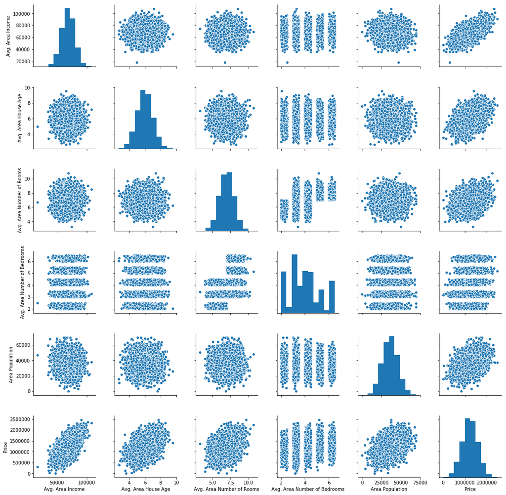

```python
sns.pairplot(df)
```

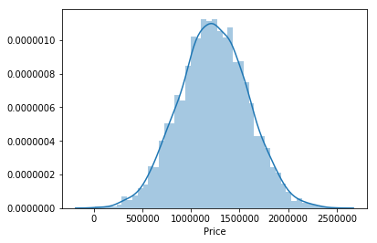

```python
sns.distplot(df['Price'])
```

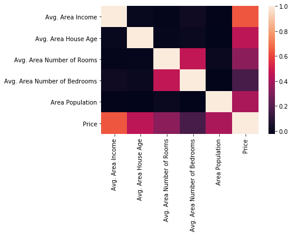

```python
sns.heatmap(df.corr())
```

```python
df.corr()
```

|  | Avg. Area Income | Avg. Area House Age | Avg. Area Number of Rooms | Avg. Area Number of Bedrooms | Area Population | Price |
| --- | --- | --- | --- | --- | --- | --- |
| Avg. Area Income | 1.000000 | -0.002007 | -0.011032 | 0.019788 | -0.016234 | 0.639734 |
| Avg. Area House Age | -0.002007 | 1.000000 | -0.009428 | 0.006149 | -0.018743 | 0.452543 |
| Avg. Area Number of Rooms | -0.011032 | -0.009428 | 1.000000 | 0.462695 | 0.002040 | 0.335664 |
| Avg. Area Number of Bedrooms | 0.019788 | 0.006149 | 0.462695 | 1.000000 | -0.022168 | 0.171071 |
| Area Population | -0.016234 | -0.018743 | 0.002040 | -0.022168 | 1.000000 | 0.408556 |
| Price | 0.639734 | 0.452543 | 0.335664 | 0.171071 | 0.408556 | 1.000000 |

# Training a Linear Regression Model

Let's now begin to train out regression model. We will need to first split up our data into an X array that contains the features to train on, and a y array with the target variable, in this case the Price column. We will toss out the Address column because it only has text info that the linear regression model can't use.

## X and y arrays

```python
X=df.drop(['Address','Price'],axis=1)
X
```

|  | Avg. Area Income | Avg. Area House Age | Avg. Area Number of Rooms | Avg. Area Number of Bedrooms | Area Population |
| --- | --- | --- | --- | --- | --- |
| 0 | 79545.458574 | 5.682861 | 7.009188 | 4.09 | 23086.800503 |
| 1 | 79248.642455 | 6.002900 | 6.730821 | 3.09 | 40173.072174 |
| 2 | 61287.067179 | 5.865890 | 8.512727 | 5.13 | 36882.159400 |
| 3 | 63345.240046 | 7.188236 | 5.586729 | 3.26 | 34310.242831 |
| 4 | 59982.197226 | 5.040555 | 7.839388 | 4.23 | 26354.109472 |
| 5 | 80175.754159 | 4.988408 | 6.104512 | 4.04 | 26748.428425 |
| 6 | 64698.463428 | 6.025336 | 8.147760 | 3.41 | 60828.249085 |
| 7 | 78394.339278 | 6.989780 | 6.620478 | 2.42 | 36516.358972 |
| 8 | 59927.660813 | 5.362126 | 6.393121 | 2.30 | 29387.396003 |
| 9 | 81885.927184 | 4.423672 | 8.167688 | 6.10 | 40149.965749 |
| 10 | 80527.472083 | 8.093513 | 5.042747 | 4.10 | 47224.359840 |
| 11 | 50593.695497 | 4.496513 | 7.467627 | 4.49 | 34343.991886 |
| 12 | 39033.809237 | 7.671755 | 7.250029 | 3.10 | 39220.361467 |
| 13 | 73163.663441 | 6.919535 | 5.993188 | 2.27 | 32326.123139 |
| 14 | 69391.380184 | 5.344776 | 8.406418 | 4.37 | 35521.294033 |
| 15 | 73091.866746 | 5.443156 | 8.517513 | 4.01 | 23929.524053 |
| 16 | 79706.963058 | 5.067890 | 8.219771 | 3.12 | 39717.813576 |
| 17 | 61929.077018 | 4.788550 | 5.097010 | 4.30 | 24595.901498 |
| 18 | 63508.194299 | 5.947165 | 7.187774 | 5.12 | 35719.653052 |
| 19 | 62085.276403 | 5.739411 | 7.091808 | 5.49 | 44922.106702 |
| 20 | 86294.999089 | 6.627457 | 8.011898 | 4.07 | 47560.775336 |
| 21 | 60835.089979 | 5.551222 | 6.517175 | 2.10 | 45574.741662 |
| 22 | 64490.650267 | 4.210323 | 5.478088 | 4.31 | 40358.960106 |
| 23 | 60697.351539 | 6.170484 | 7.150537 | 6.34 | 28140.967088 |
| 24 | 59748.855487 | 5.339340 | 7.748682 | 4.23 | 27809.986544 |
| 25 | 56974.476539 | 8.287562 | 7.312880 | 4.33 | 40694.869513 |
| 26 | 82173.626076 | 4.018525 | 6.992699 | 2.03 | 38853.918066 |
| 27 | 64626.880978 | 5.443360 | 6.988754 | 4.00 | 27784.742280 |
| 28 | 90499.057451 | 6.384359 | 4.242191 | 3.04 | 33970.164990 |
| 29 | 59323.792100 | 6.977828 | 8.273697 | 4.07 | 37520.657732 |
| ... | ... | ... | ... | ... | ... |
| 4970 | 55980.204807 | 7.014510 | 5.458789 | 2.11 | 43968.687046 |
| 4971 | 73491.134427 | 5.784430 | 4.425959 | 3.37 | 30800.541060 |
| 4972 | 83695.272383 | 7.643507 | 7.127219 | 5.05 | 33113.759057 |
| 4973 | 78743.759274 | 6.583685 | 6.595683 | 4.07 | 24381.144540 |
| 4974 | 70720.296463 | 6.411801 | 5.048128 | 3.01 | 19114.019253 |
| 4975 | 54037.580879 | 8.471765 | 6.966072 | 3.27 | 28696.170856 |
| 4976 | 75046.313791 | 5.351169 | 7.797825 | 5.23 | 34107.888619 |
| 4977 | 75980.438843 | 6.583105 | 5.914892 | 3.23 | 40394.593489 |
| 4978 | 80393.339500 | 8.899713 | 5.652974 | 4.04 | 39547.932489 |
| 4979 | 82224.695006 | 5.434087 | 8.375708 | 3.12 | 57166.867510 |
| 4980 | 75664.024482 | 5.789203 | 6.415312 | 2.02 | 54724.251275 |
| 4981 | 71663.871293 | 6.150745 | 7.311907 | 6.33 | 24109.778060 |
| 4982 | 58800.908770 | 5.976507 | 7.304051 | 6.43 | 37426.709745 |
| 4983 | 69655.183954 | 7.721100 | 6.077795 | 4.29 | 32902.355584 |
| 4984 | 62623.359828 | 5.071624 | 6.771015 | 3.33 | 50985.971202 |
| 4985 | 75117.042949 | 6.036275 | 6.538111 | 2.22 | 43976.031060 |
| 4986 | 71060.406015 | 5.718839 | 7.222730 | 4.34 | 34814.585591 |
| 4987 | 65729.222330 | 6.237787 | 6.860475 | 3.12 | 25573.854289 |
| 4988 | 67637.840665 | 7.056673 | 5.774409 | 3.05 | 43846.531340 |
| 4989 | 47965.406896 | 5.694638 | 7.363327 | 5.40 | 46071.947337 |
| 4990 | 52723.876555 | 5.452237 | 8.124571 | 6.39 | 14802.088438 |
| 4991 | 74102.191890 | 5.657841 | 7.683993 | 3.13 | 24041.270592 |
| 4992 | 87499.125743 | 6.403473 | 4.836091 | 4.02 | 40815.199679 |
| 4993 | 69639.140896 | 5.007510 | 7.778375 | 6.05 | 54056.128430 |
| 4994 | 73060.846226 | 5.293682 | 6.312253 | 4.16 | 22695.695480 |
| 4995 | 60567.944140 | 7.830362 | 6.137356 | 3.46 | 22837.361035 |
| 4996 | 78491.275435 | 6.999135 | 6.576763 | 4.02 | 25616.115489 |
| 4997 | 63390.686886 | 7.250591 | 4.805081 | 2.13 | 33266.145490 |
| 4998 | 68001.331235 | 5.534388 | 7.130144 | 5.44 | 42625.620156 |
| 4999 | 65510.581804 | 5.992305 | 6.792336 | 4.07 | 46501.283803 |

5000 rows × 5 columns

```python
y=df['Price']
y
```

```
0       1.059034e+06
1       1.505891e+06
2       1.058988e+06
3       1.260617e+06
4       6.309435e+05
5       1.068138e+06
6       1.502056e+06
7       1.573937e+06
8       7.988695e+05
9       1.545155e+06
10      1.707046e+06
11      6.637324e+05
12      1.042814e+06
13      1.291332e+06
14      1.402818e+06
```

[output cut: 47 more lines]

## Train Test Split

Now let's split the data into a training set and a testing set. We will train out model on the training set and then use the test set to evaluate the model.

```python
from sklearn.model_selection import train_test_split
X_train,X_test,y_train,y_test=train_test_split(X,y,test_size=0.4,random_state=101)
```

## Creating and Training the Model

```python
from sklearn.linear_model import LinearRegression
lm=LinearRegression()
lm.fit(X_train,y_train)
```

```
LinearRegression(copy_X=True, fit_intercept=True, n_jobs=1, normalize=False)
```

## Model Evaluation

Let's evaluate the model by checking out it's coefficients and how we can interpret them.

```python
print(lm.intercept_)
```

```
-2640159.7968526687
```

```python
df_coeff=pd.DataFrame(lm.coef_,X.columns,columns=['coeffecients'])
df_coeff
```

|  | coeffecients |
| --- | --- |
| Avg. Area Income | 21.528276 |
| Avg. Area House Age | 164883.282027 |
| Avg. Area Number of Rooms | 122368.678027 |
| Avg. Area Number of Bedrooms | 2233.801864 |
| Area Population | 15.150420 |

## Interpreting the coefficients:

Holding all other features fixed, a 1 unit increase in Avg. Area Income is associated with an increase of $21.52 .

Holding all other features fixed, a 1 unit increase in Avg. Area House Age is associated with an increase of $164883.28 .

Holding all other features fixed, a 1 unit increase in Avg. Area Number of Rooms is associated with an increase of $122368.67 .

Holding all other features fixed, a 1 unit increase in Avg. Area Number of Bedrooms is associated with an increase of $2233.80 .

Holding all other features fixed, a 1 unit increase in Area Population is associated with an increase of $15.15

## Predictions from our Model

Let's grab predictions off our test set and see how well it did!

```python
predictions=lm.predict(X_test)
```

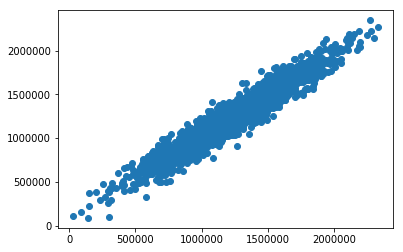

```python
plt.scatter(y_test,predictions)
```

## Regression Evaluation Metrics

```python
from sklearn.metrics import mean_absolute_error
print(mean_absolute_error(y_test,predictions))
```

```
82288.22251914942
```